# COMPSCIX 415.2 Homework 6

# Exercise 2

1.Generate a random sample of size n = 10000 from a gamma(1,2) distribution and plot a histogram or density curve. Use the code below to help you get your sample.

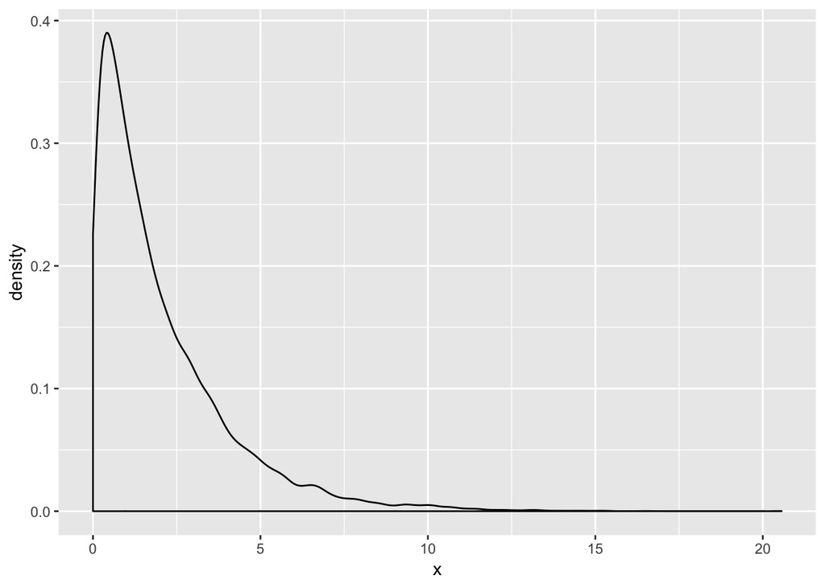

```r
library(tidyverse)
n <- 10000
# look at ?rgamma to read about this function
?rgamma
gamma_samp <- tibble(x = rgamma(n, shape = 1, scale = 2))
ggplot(data = gamma_samp, mapping = aes(x = x)) +
  geom_density()
```

2.What is the mean and standard deviation of your sample? They should both be close to 2 because for a gamma distribution: mean = shape x scale variance = shape x scale^2

```r
mean(gamma_samp$x)
```

```
## [1] 2.005836
```

```r
sd(gamma_samp$x)
```

```
## [1] 2.010605
```

3.Pretend the distribution of our *population* of data looks like the plot above. Now take a sample of size n = 30 from a Gamma(1,2) distribution, plot the histogram or density curve, and calculate the mean and standard deviation.

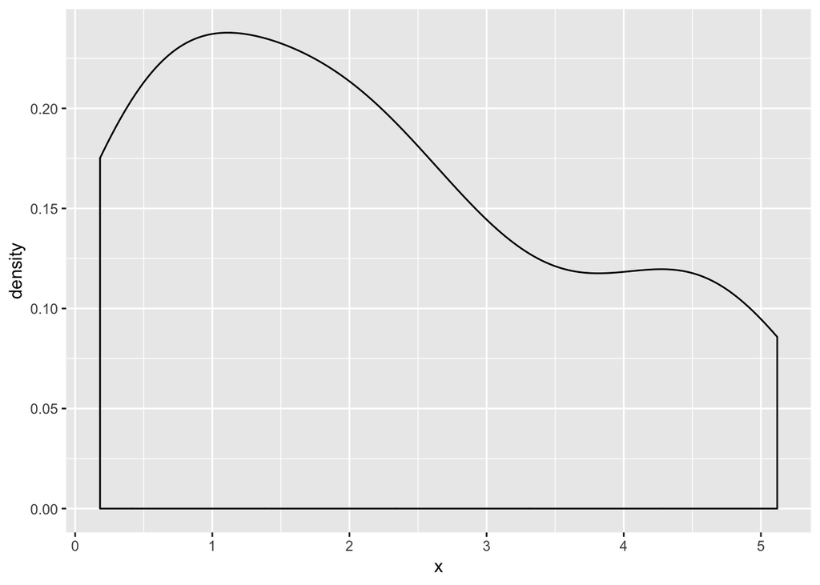

```r
gamma_samp_30 <- tibble(x = rgamma(30, shape = 1, scale = 2))

ggplot(data = gamma_samp_30, mapping = aes(x = x)) +
  geom_density()
```

```r
mean(gamma_samp_30$x)
```

```
## [1] 2.151507
```

```r
sd(gamma_samp_30$x)
```

```
## [1] 1.556032
```

4.Take a sample of size n = 30, again from the Gamma(1,2) distribution, calculate the mean, and assign it to a vector named `mean_samp`. Repeat this 10000 times!!!! The code below might help.

```r
# create a vector with 10000 NAs
mean_samp <- rep(NA, 10000)
# start a loop
for(i in 1:10000) {
  g_samp <- rgamma(30, shape = 1, scale = 2)
  mean_samp[i] <- mean(g_samp)
}
# Convert vector to a tibble
mean_samp <- tibble(mean_samp)
```

5.Make a histogram of your collection of means from above (`mean_samp`).

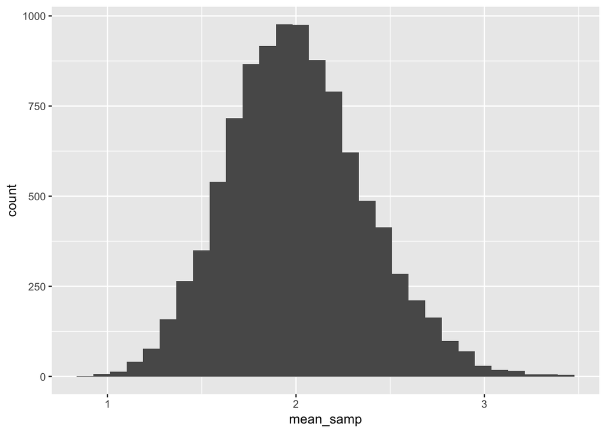

```r
ggplot(mean_samp, mapping = aes(x = mean_samp)) +
  geom_histogram()
```

6.Calculate the mean and standard deviation of all of your sample means.

```r
mean(mean_samp$mean_samp)
```

```
## [1] 2.006567
```

```r
sd(mean_samp$mean_samp)
```

```
## [1] 0.364174
```

7.Did anything surprise you about your answers to #6?

It looks normal.

```r
# create a vector with 10000 NAs
new_mean_samp <- rep(NA, 10000)
# start a loop
for(i in 1:10000) {
  new_g_samp <- rgamma(300, shape = 1, scale = 2)
  new_mean_samp[i] <- mean(new_g_samp)
}
# Convert vector to a tibble
new_mean_samp <- tibble(new_mean_samp)

mean(new_mean_samp$new_mean_samp)
```

```
## [1] 2.001569
```

```r
sd(new_mean_samp$new_mean_samp)
```

```
## [1] 0.1160401
```

Yes, thay match with what theorem states.